# Luis_Garcia_CaseStudy1

Luis Garcia

2022-10-22

## 1. How many breweries are present in each state

```
##
##  AK  AL  AR  AZ  CA  CO  CT  DC  DE  FL  GA  HI  IA  ID  IL  IN  KS  KY  LA  MA
##   7   3   2  11  39  47   8   1   2  15   7   4   5   5  18  22   3   4   5  23
##  MD  ME  MI  MN  MO  MS  MT  NC  ND  NE  NH  NJ  NM  NV  NY  OH  OK  OR  PA  RI
##   7   9  32  12   9   2   9  19   1   5   3   3   4   2  16  15   6  29  25   5
##  SC  SD  TN  TX  UT  VA  VT  WA  WI  WV  WY
##   4   1   3  28   4  16  10  23  20   1   4
```

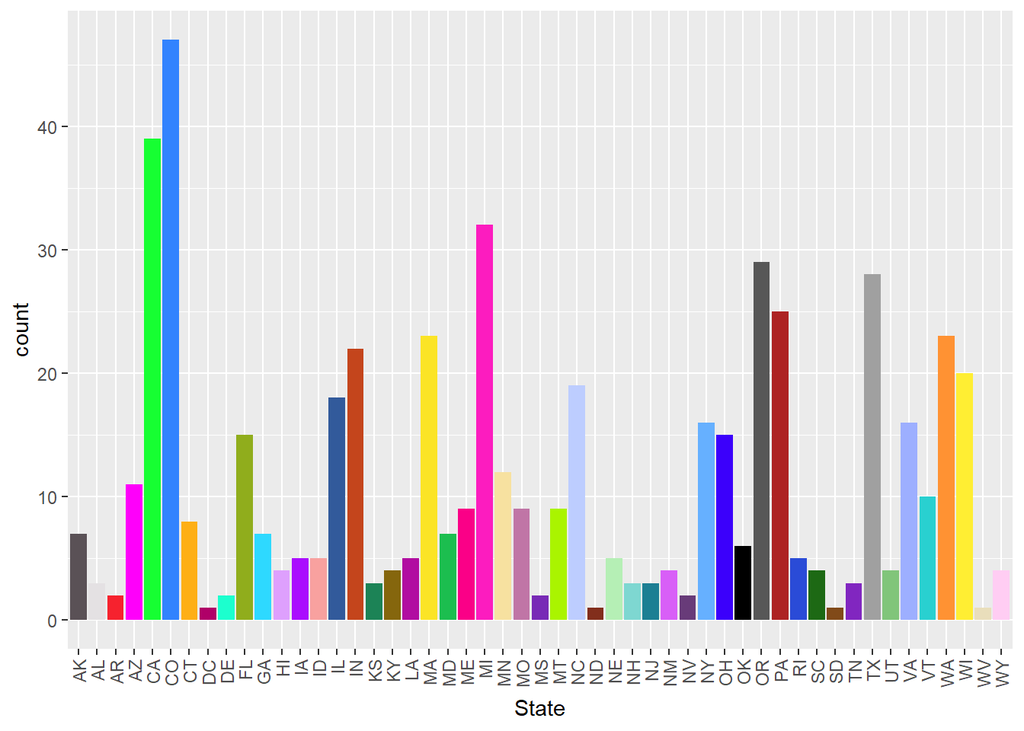

## 2. Merge beer data with the breweries data. Print the first 6 observations and the last six observations to check the merged file. (RMD only, this does not need to be included in the presentation or the deck.)

### First 6 observations

```
##   Brew_ID             Name.x        City State        Name.y Beer_ID   ABV IBU
## 1       1 NorthGate Brewing  Minneapolis    MN       Pumpion    2689 0.060  38
## 2       1 NorthGate Brewing  Minneapolis    MN    Stronghold    2688 0.060  25
## 3       1 NorthGate Brewing  Minneapolis    MN   Parapet ESB    2687 0.056  47
## 4       1 NorthGate Brewing  Minneapolis    MN  Get Together    2692 0.045  50
## 5       1 NorthGate Brewing  Minneapolis    MN Maggie's Leap    2691 0.049  26
## 6       1 NorthGate Brewing  Minneapolis    MN    Wall's End    2690 0.048  19
##                                 Style Ounces
## 1                         Pumpkin Ale     16
## 2                     American Porter     16
## 3 Extra Special / Strong Bitter (ESB)     16
## 4                        American IPA     16
## 5                  Milk / Sweet Stout     16
## 6                   English Brown Ale     16
```

### Last 6 observations

```
##      Brew_ID                        Name.x          City State
## 2405     556         Ukiah Brewing Company         Ukiah    CA
## 2406     557       Butternuts Beer and Ale Garrattsville    NY
## 2407     557       Butternuts Beer and Ale Garrattsville    NY
## 2408     557       Butternuts Beer and Ale Garrattsville    NY
## 2409     557       Butternuts Beer and Ale Garrattsville    NY
## 2410     558 Sleeping Lady Brewing Company     Anchorage    AK
##                         Name.y Beer_ID   ABV IBU                   Style Ounces
## 2405             Pilsner Ukiah      98 0.055  NA         German Pilsener     12
## 2406         Porkslap Pale Ale      49 0.043  NA American Pale Ale (APA)     12
## 2407           Snapperhead IPA      51 0.068  NA            American IPA     12
## 2408         Moo Thunder Stout      50 0.049  NA      Milk / Sweet Stout     12
## 2409  Heinnieweisse Weissebier      52 0.049  NA              Hefeweizen     12
## 2410 Urban Wilderness Pale Ale      30 0.049  NA        English Pale Ale     12
```

## 3. Address the missing values in each column.

```r
hello_NA = hello_merge[!complete.cases(hello_merge),]
dim(hello_NA)
```

```
## [1] 1005   10
```

```
##    Brew_ID                    Name.x       City State          Name.y Beer_ID
## 19       2 Against the Grain Brewery Louisville    KY  Kamen Knuddeln    2676
## 35       6     COAST Brewing Company Charleston    SC        Rye Knot    2656
## 36       6     COAST Brewing Company Charleston    SC        Dead Arm    2655
## 37       6     COAST Brewing Company Charleston    SC 32°/50° Kölsch     2654
## 38       6     COAST Brewing Company Charleston    SC      Blackbeard    2657
## 39       6     COAST Brewing Company Charleston    SC        Boy King    2652
##      ABV IBU                            Style Ounces
## 19 0.065  NA                American Wild Ale     16
## 35 0.062  NA               American Brown Ale     12
## 36 0.060  NA          American Pale Ale (APA)     12
## 37 0.048  NA                           Kölsch     16
## 38 0.093  NA American Double / Imperial Stout     12
## 39 0.097  NA   American Double / Imperial IPA     16
```

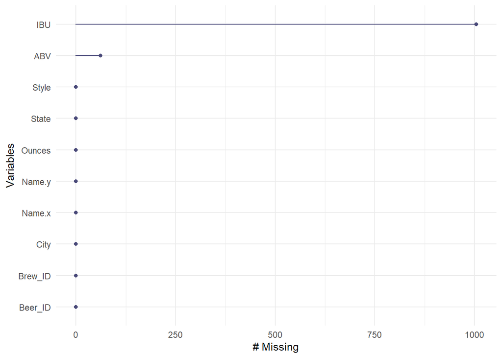

## 4. Compute the median alcohol content and international bitterness unit for each state. Plot a bar chart to compare.

```
## # A tibble: 6 × 3
##   State medianABV count
##   <chr>     <dbl> <int>
## 1 " AK"    0.056     25
## 2 " AL"    0.06      10
## 3 " AR"    0.052      5
## 4 " AZ"    0.055     47
## 5 " CA"    0.058    183
## 6 " CO"    0.0605   265
```

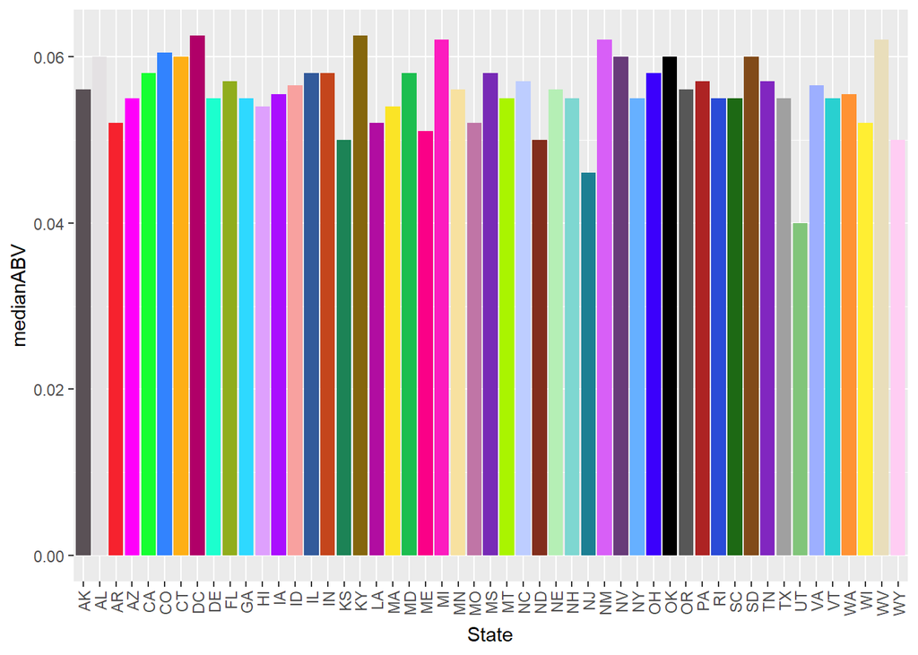

```
## # A tibble: 6 × 3
##   State medianIBU count
##   <chr>     <dbl> <int>
## 1 " AK"      46      25
## 2 " AL"      43      10
## 3 " AR"      39       5
## 4 " AZ"      20.5    47
## 5 " CA"      42     183
## 6 " CO"      40     265
```

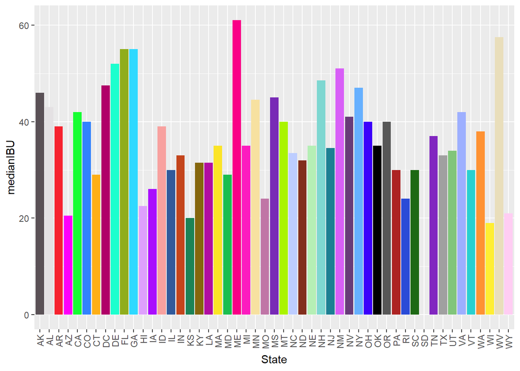

## 5. Which state has the maximum alcoholic (ABV) beer? Which state has the most bitter (IBU) beer?

```
## # A tibble: 6 × 2
##   State max_alc
##   <chr>   <dbl>
## 1 " CO"   0.128
## 2 " KY"   0.125
## 3 " IN"   0.12
## 4 " NY"   0.1
## 5 " CA"   0.099
## 6 " ID"   0.099
```

```
## # A tibble: 6 × 2
##   State max_ibu
##   <chr>   <dbl>
## 1 " OR"     138
## 2 " VA"     135
## 3 " MA"     130
## 4 " OH"     126
## 5 " MN"     120
## 6 " VT"     120
```

### Colorado has the maximum ABV.

### Oregon has the maximum IBU.

## 6. Comment on the summary statistics and distribution of the ABV variable.

```
##    Min. 1st Qu.  Median    Mean 3rd Qu.    Max.    NA's
## 0.00100 0.05000 0.05600 0.05977 0.06700 0.12800      62
```

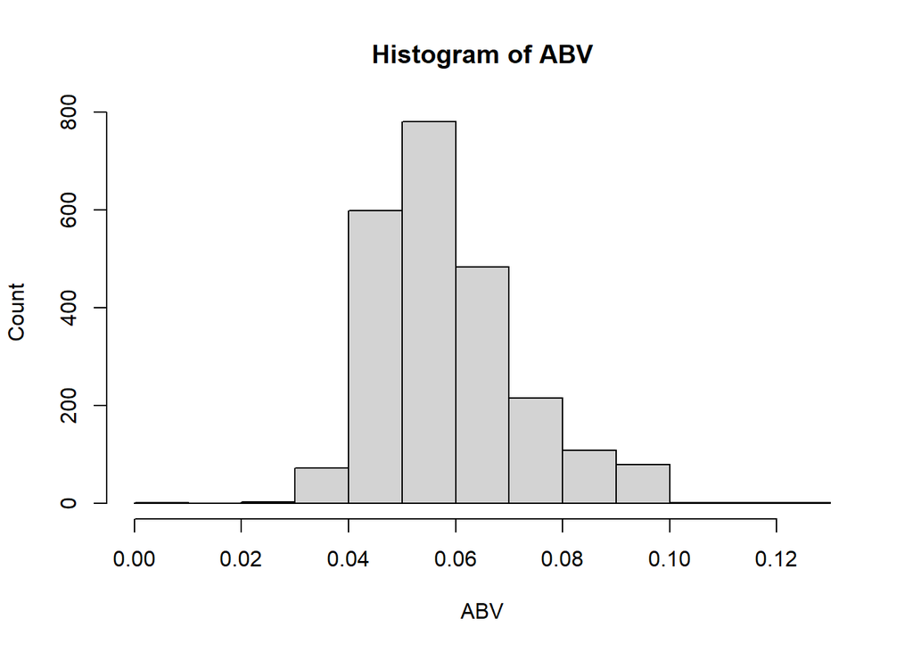

## 7. Is there an apparent relationship between the bitterness of the beer and its alcoholic content? Draw a scatter plot. Make your best judgment of a relationship and EXPLAIN your answer.

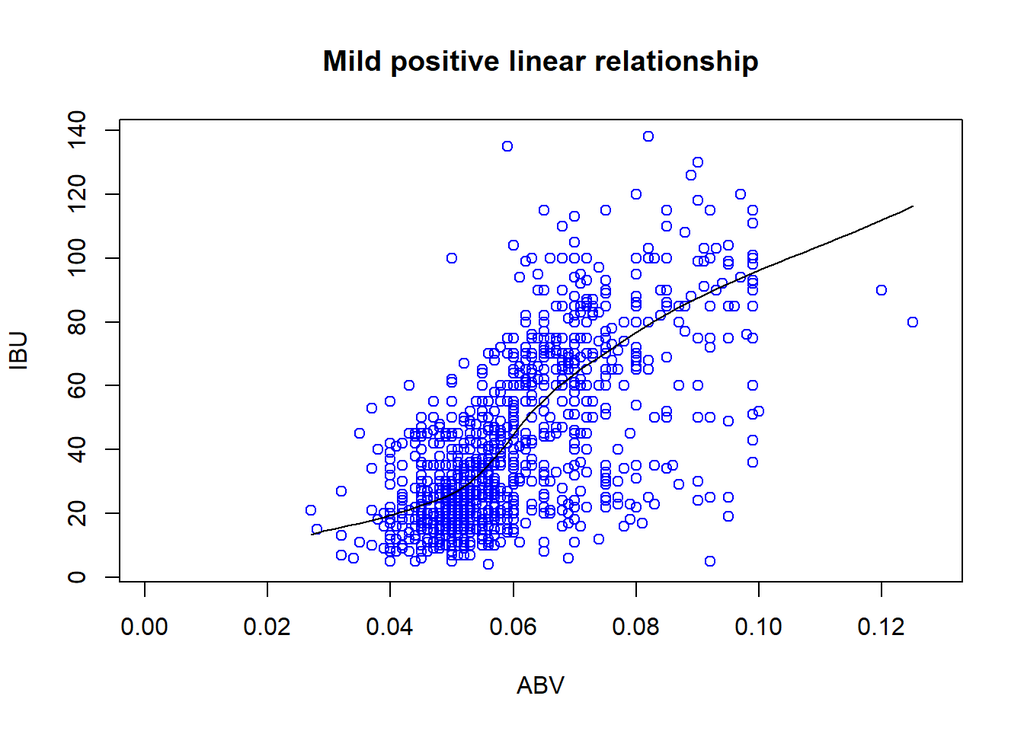

### This data shows mild positive linear relationship between bitterness and alcoholic content(3rd degree polynomial). Most of Beer bitterness comes from hops.

## 8. Budweiser KNN model ABV and IBU to predict beer style

## Run KNN model with K of 17, the best K

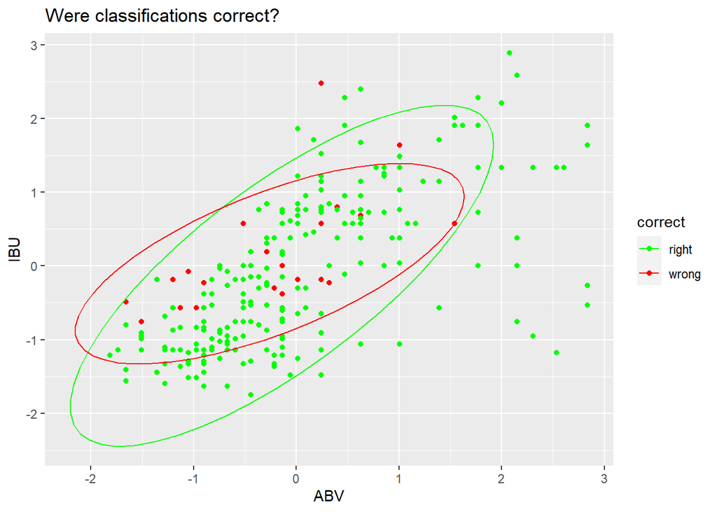

```r
test_IPA_and_Ale %>% ggplot(aes(x = ABV, y = IBU, color = correct)) + geom_point() + stat_ellipse() + scale_color_manual(values = c('green','red')) + ggtitle('Were classifications correct?')
```

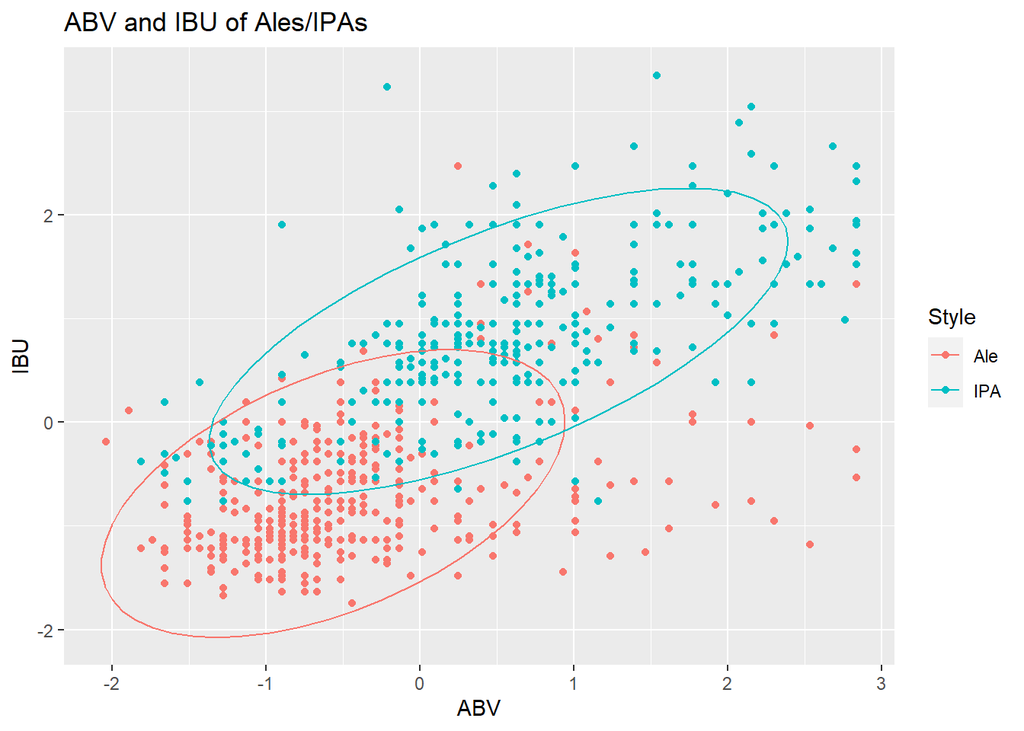

```r
IPA_and_Ale %>% ggplot(aes(x = ABV, y = IBU, color=Style)) +
geom_point() +
stat_ellipse()+ ggtitle('ABV and IBU of Ales/IPAs')
```

### Most of the errors in prediction occus at an ABV of (0.04210285 0.07490283) while most errors for IBU occur at (23.66415 ,76.24263). This makes sense as though most ales are lower on ABV and IBU than IPAs, they overlap the most in this area.

## 9.Market Share Analysis to find the best IBU and ABV values of the top three breweries, then run our KNN model to determine the best type of beer for the Texas market.

```
##   Brew_ID  n                     Name          City State
## 1      26 32 Sun King Brewing Company  Indianapolis    IN
## 2      47 23      Sixpoint Craft Ales      Brooklyn    NY
## 3      81 22   Hopworks Urban Brewery      Portland    OR
## 4     132 20    Stevens Point Brewery Stevens Point    WI
## 5     166 20   Great Crescent Brewery        Aurora    IN
## 6     167 20      Oskar Blues Brewery      Longmont    CO
```

```
##  [1] "Brew_ID" "Name.x"  "City"    "State"   "Name.y"  "Beer_ID" "ABV"
##  [8] "IBU"     "Style"   "Ounces"
```

```
##    Brew_ID                    Name.x        City State         Name.y Beer_ID
## 1        1        NorthGate Brewing  Minneapolis    MN        Pumpion    2689
## 6        1        NorthGate Brewing  Minneapolis    MN     Wall's End    2690
## 7        2 Against the Grain Brewery  Louisville    KY         A Beer    2683
## 13       2 Against the Grain Brewery  Louisville    KY  Flesh Gourd'n    2681
## 14       2 Against the Grain Brewery  Louisville    KY       Sho'nuff    2680
## 16       2 Against the Grain Brewery  Louisville    KY The Brown Note    2674
##           ABV        IBU Style Ounces
## 1  -0.1358872 -0.4546876   Ale     16
## 6  -1.0505221 -1.1774168   Ale     16
## 7  -1.5078395 -0.3025341   Ale     16
## 13  0.3214302 -1.1013400   Ale     16
## 14 -1.6602787 -1.4056471   Ale     16
## 16 -0.8980830 -1.1393784   Ale     16
```

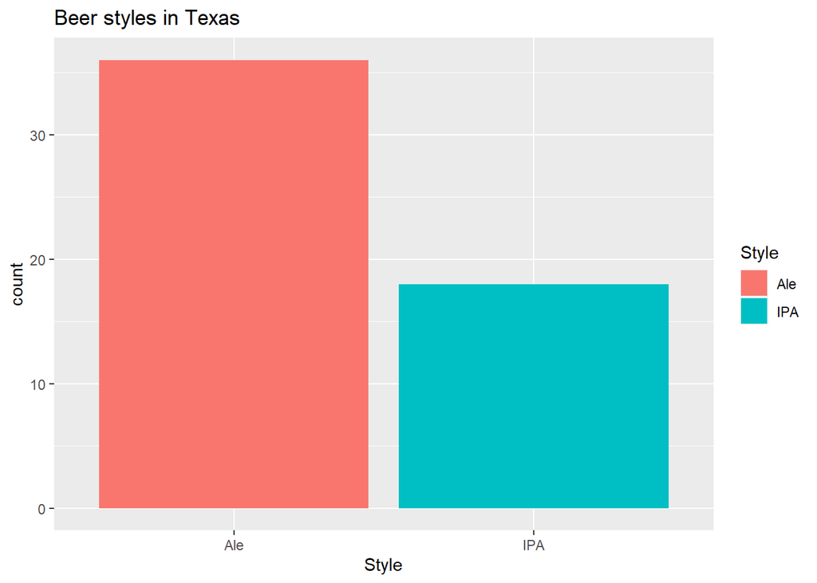

## 9.2 What is the best, optimized ABV and IBU in Texas market compared to the best three markets?

### Fom our analysis of the mean of the three top breweries, we see that the best mean ABV and IBU value are .07107 and 54.65313.

```
## [1] Ale
## attr(,"prob")
## [1] 0.7142857
## Levels: Ale IPA
```

### These values would most likely be classified as Ale. Thus we recommend to follow Ale brewing methods.